# Basic Tutorial

Jakub Wiśniewski

# 1 fairmodels

In this tutorial you will get to know when, why and how to use `fairmodels`. `fairmodels` is a tool for bias detection, visualization and mitigation. It is compatible with `DALEX` (Biecek (2018)) and `DALEXtra` which are model agnostic explainers. Some knowledge of how to use those explainers will be needed but in this tutorial you should grasp the idea.

For this tutorial we will use `compas` data (Angwin et al. (2016)) to see if someone will become recidivist in next 2 years.

## 1.1 Why?

Let’s say you are building algorithm for court system that predicts if someone will become recidivist in the future. First you gather information then you build a model and predict outcomes. You get satisfying accuracy. It is pretty good, but it appears that the model is more likely to say that African Americans will become recidivists. It was trained on data that where discrimination of certain ethnic groups was visible. Racist algorithms are no good for the court system. So now we have some options. First one is to gather more reliable data, and the second one is trying to understand bias and choose model with least amount of it. We will choose the second option.

## 1.2 Data

We will use modified ProPublica’s compas data to represent our problem.

```r
library(fairmodels)
data("compas")

head(compas)
```

|  | Two_yr_Recidivism | Number_of_Priors | Age_Above_FourtyFive | Age_Below_TwentyFive | Misdemeanor | Ethnicity | Sex |
| --- | --- | --- | --- | --- | --- | --- | --- |
| 1 | 0 | 0 | 1 | 0 | 0 | Other | Male |
| 2 | 1 | 0 | 0 | 0 | 0 | African_American | Male |
| 3 | 1 | 4 | 0 | 1 | 0 | African_American | Male |
| 4 | 0 | 0 | 0 | 0 | 1 | Other | Male |
| 5 | 1 | 14 | 0 | 0 | 0 | Caucasian | Male |
| 6 | 0 | 3 | 0 | 0 | 0 | Other | Male |

For `fairmodels` package to work properly we want to flip factor levels in target variable, so positive outcome (not being a recidivist) is being predicted by models. It is only needed for one specific function but more on it later.

```r
compas$Two_yr_Recidivism <- as.factor(ifelse(compas$Two_yr_Recidivism == '1', '0', '1'))
```

## 1.3 Basic features

We train a `ranger` (Wright and Ziegler (2017)) model and create an explainer with `DALEX`.

```r
library(DALEX)
library(ranger)

# train
rf_compas <- ranger(Two_yr_Recidivism ~., data = compas, probability = TRUE)

# numeric target values
y_numeric <- as.numeric(compas$Two_yr_Recidivism)-1

# explainer
rf_explainer <- explain(rf_compas, data = compas[,-1], y = y_numeric, colorize = FALSE)
```

```
#> Preparation of a new explainer is initiated
#>   -> model label       :  ranger  (  default  )
#>   -> data              :  6172  rows  6  cols
#>   -> target variable   :  6172  values
#>   -> predict function  :  yhat.ranger  will be used (  default  )
#>   -> predicted values  :  No value for predict function target column. (  default  )
#>   -> model_info        :  package ranger , ver. 0.17.0 , task classification (  default  )
#>   -> predicted values  :  numerical, min =  0.1543542 , mean =  0.5450956 , max =  0.8659097
#>   -> residual function :  difference between y and yhat (  default  )
#>   -> residuals         :  numerical, min =  -0.8478884 , mean =  -0.0002154476 , max =  0.7884737
#>   A new explainer has been created!
```

### 1.3.1 fairness check

Than we create call function `fairness_check()` This function aggregates many explainers so you may compare many models. We assign object to name `fobject` which is short version of `fairness_object` - object returned by `fairness_check()`,

```r
fobject <- fairness_check(rf_explainer,                         # explainer
                          protected = compas$Ethnicity,         # protected variable as factor
                          privileged = "Caucasian",             # level in protected variable, potentially more privileged
                          cutoff = 0.5,                         # cutoff - optional, default = 0.5
                          colorize = FALSE)
```

```
#> Creating fairness classification object
#> -> Privileged subgroup       : character ( Ok  )
#> -> Protected variable        : factor ( Ok  )
#> -> Cutoff values for explainers  : 0.5 ( for all subgroups )
#> -> Fairness objects      : 0 objects
#> -> Checking explainers       : 1 in total (  compatible  )
#> -> Metric calculation        : 13/13 metrics calculated for all models
#>  Fairness object created succesfully
```

Let’s see if our ranger model has bias.

```r
print(fobject, colorize = FALSE)
```

```
#>
#> Fairness check for models: ranger
#>
#> ranger passes 3/5 metrics
#> Total loss :  3.490967
```

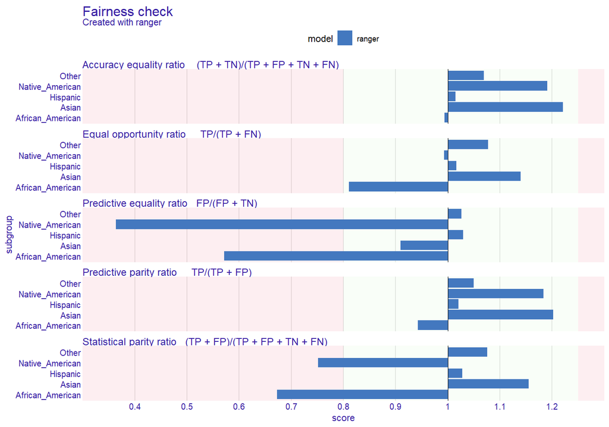

```r
plot(fobject)
```

Of course the `protected` parameter can be changed, for example to (here binary) `compas$Sex`.

In many metrics `ranger` exceeds fairness threshold (which can be changed by `epsilon` parameter). If bars reach red field on the left it means that there is bias towards certain unprivileged subgroup. If they reach one on the right it means bias towards privileged (Caucasian - in all metrics here Caucasian subgroup is referenced as base - 1) subgroup. This values mean the proportion (ratio) of certain unprivileged subgroup to privileged subgroup (eg. Asian/Caucasian). By default it represents 80% rule (for eg. women should get credit at rate at least 80% of that of men) (Code of Federal Regulations (1978)) . Metrics measure how equal treatment and mistreatment among subgroups is. More on those metrics: wikipedia and in Verma and Rubin (2018)

Why do we have this bias? Model did learn from biased data. We can see it on plot below

### 1.3.2 plot density

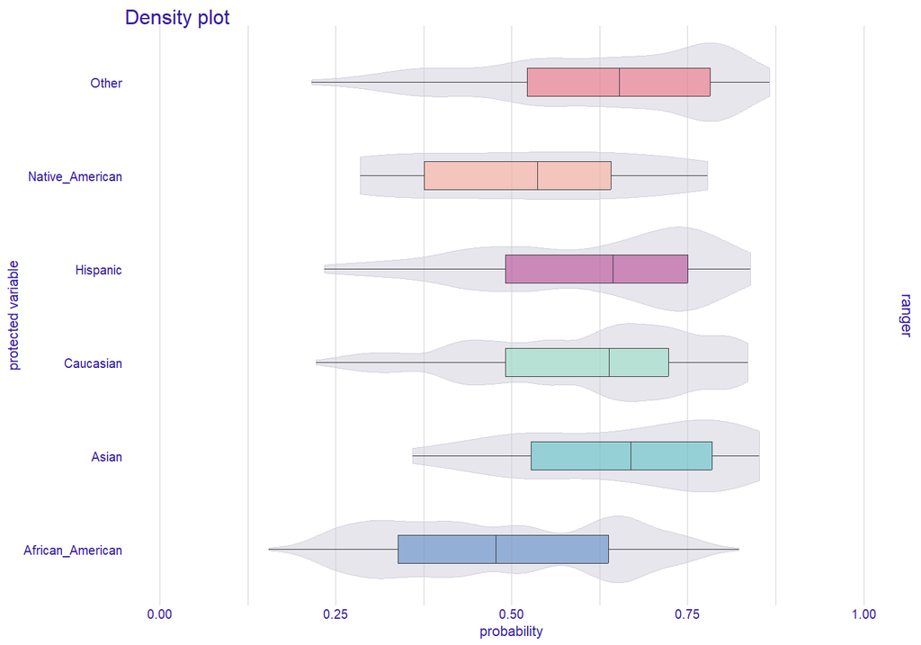

```r
plot_density(fobject)
```

As we can see it is more likely that model will categorize African Americans as being recidivists than for example Asians.

### 1.3.3 Metric scores plot

Sometimes it is worth it to see what the raw (unscaled) metrics are. User could use `fobject$groups_data` but the easier way is to plot `metric_scores` object.

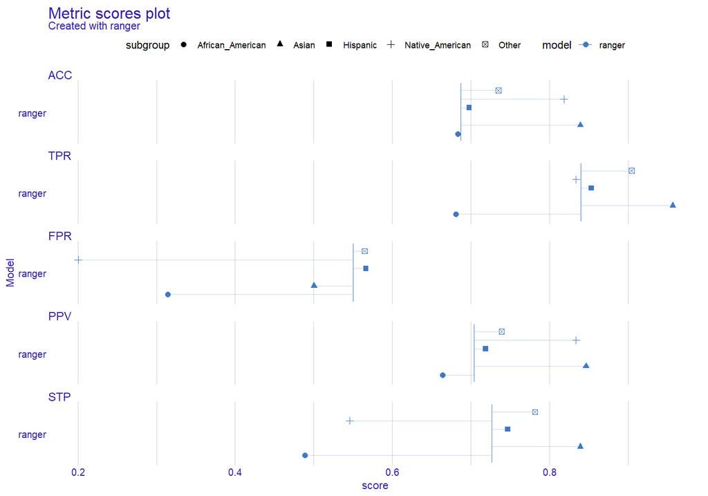

```r
plot(metric_scores(fobject))
```

## 1.4 fairness object - idea

To really see what `fairness_object` is about, we need to make some more models and explainers.

```r
library(gbm)

rf_compas_1 <- ranger(Two_yr_Recidivism ~Number_of_Priors+Age_Below_TwentyFive,
                      data = compas,
                      probability = TRUE)

lr_compas_1 <- glm(Two_yr_Recidivism~.,
                   data=compas,
                   family=binomial(link="logit"))

rf_compas_2 <- ranger(Two_yr_Recidivism ~., data = compas, probability = TRUE)
rf_compas_3 <- ranger(Two_yr_Recidivism ~ Age_Above_FourtyFive+Misdemeanor,
                      data = compas,
                      probability = TRUE)

df <- compas
df$Two_yr_Recidivism <- as.numeric(compas$Two_yr_Recidivism)-1
gbm_compas_1<- gbm(Two_yr_Recidivism~., data = df)

explainer_1 <- explain(rf_compas_1,  data = compas[,-1], y = y_numeric)
explainer_2 <- explain(lr_compas_1,  data = compas[,-1], y = y_numeric)
explainer_3 <- explain(rf_compas_2,  data = compas[,-1], y = y_numeric, label = "ranger_2")
explainer_4 <- explain(rf_compas_3,  data = compas[,-1], y = y_numeric, label = "ranger_3")
explainer_5 <- explain(gbm_compas_1, data = compas[,-1], y = y_numeric)
```

Now we create one object with all explainers

```r
fobject <- fairness_check(explainer_1, explainer_2,
                            explainer_3, explainer_4,
                            explainer_5,
                            protected = compas$Ethnicity,
                            privileged = "Caucasian",
                            verbose = FALSE)
```

As we can see there is some parameters in fairness_check such as:  
1. x, … - list of `DALEX` explainers, and other `fairness_object` objects  
2. protected - factor, containing subgroups as levels. Protected stands for protected variable (or sensitive attribute)  
3. privileged - character, level in protected, it is subgroup suspected of having better results  
4. cutoff - numeric, vector of cutoffs values matching the order of levels in protected variable. It affects only explainers so if `fairness_object` is passed it’s cutoff vector won’t be changed.  
5. label - character, vector of labels for explainers only. Very convenient for `fairness_check()` iterative approach - having explainer, checking for bias, mitigating bias, passing both explainer and fairness object and comparing fairness.  
6. epsilon - numeric, boundary position in `fairness_check()`. Fairness metrics are satisfied if parity loss values are between (-epsilon, epsilon)

### 1.4.1 What consists of fairness object?

`fairness_object` is output value of `fairness_check()` It is S3 object consisting of: * Parity loss metrics Popular confusion matrix metrics with parity loss - sum of absolute logarithms of ratios of unprivileged subgroups and privileged one (more on that in documentation `?fairness_check`. If model would have 0 in certain parity loss metric it would mean that it treats all subgroups equally.

```r
fobject$parity_loss_metric_data
```

| TPR | TNR | PPV | NPV | FNR | FPR | FDR | FOR | TS | STP | ACC | F1 | NEW_METRIC |
| --- | --- | --- | --- | --- | --- | --- | --- | --- | --- | --- | --- | --- |
| 0.6543728 | 0.9564557 | 0.4340678 | 0.4943407 | 2.0933227 | 1.6062123 | 1.2928436 | 0.7714054 | 0.6637935 | 1.1133131 | 0.4133125 | 0.4164699 | 2.747695 |
| 0.5471779 | NA | 0.1630229 | NA | 3.2047184 | 1.9228318 | 0.3724644 | 1.7116794 | 0.5362121 | 1.1034842 | 0.1969839 | 0.3361082 | 3.751896 |
| 0.5548253 | 1.3023256 | 0.4415397 | 0.6414770 | 2.9787647 | 1.9526388 | 1.4461577 | 1.5975985 | 0.8055987 | 1.0804344 | 0.4632349 | 0.4922240 | 3.533590 |
| 0.6611125 | 0.7401031 | 0.7674172 | 0.8209521 | 0.8762755 | 0.8532876 | 1.4329174 | 0.6729784 | 0.8970468 | 0.5742171 | 0.3638060 | 0.6304323 | 1.537388 |
| 0.4414848 | 2.4183838 | 0.3752312 | 1.1141293 | 2.0415691 | 2.1587813 | 1.0737568 | 1.6418875 | 0.6546808 | 1.0316153 | 0.3576842 | 0.4053578 | 2.483054 |

- groups_data

Fairness object gets metrics based on confusion matrix and checks them over the groups.

```r
# for the first model
fobject$groups_data$ranger$TPR
```

```
#> African_American            Asian        Caucasian         Hispanic
#>        0.6129458        0.8695652        0.7533177        0.8062500
#>  Native_American            Other
#>        0.6666667        0.8447489
```

It is simply metrics for certain subgroup.

What is relation between `$groups_data` and `$parity_loss_metric_data` ?

If we were going only to take score from certain metric (Let’s say fpr and 0.3) we wouldn’t know if it is good or bad. But we are aiming for **equal treatment over all groups** so if this metric score would be the same in all groups it would be very good. But the metrics wouldn’t be comparable between each others (fpr - 0.3 in all groups and accuracy - 0.9 in all groups, both are good in terms of parity). That is why we use **privileged** - to set benchmark. And for example Caucasian in fpr had score of 0.3 and African American 0.6. After setting `privilieged = Caucasian` Caucasian would have score 0, and African American `log(0.6/0.3)`. It enables comparing and adding scores.

*Note: When dealing with plots we use formula sum(abs(log(Mu/Mp))) for all unprivileged metrics (Mu - metric unprivileged, Mp - metric privileged) to represent aggregated score in subgroups. In short is how much it differs from ideal scores. The closer to zero the better*

- group_confusion_matrices Similarly to groups data it stores confusion matrix for each subgroup
- explainers

list of `DALEX` explainers

- cutoff

```r
# for first model
fobject$cutoff$ranger
```

```
#> $African_American
#> [1] 0.5
#>
#> $Asian
#> [1] 0.5
#>
#> $Caucasian
#> [1] 0.5
#>
#> $Hispanic
#> [1] 0.5
#>
#> $Native_American
#> [1] 0.5
#>
#> $Other
#> [1] 0.5
```

list of cutoff values for each model

- fairness_check_data data used in print and plot of `fairness_object`. It is already processed data and ready to plot. If someone were to use `abs()` metrics there would be equal to particular metrics in `$parity_loss_metric_data`. It means that it allows negative values. So when value is negative it means that score of privileged group in this metric was better.
- … - other parameters passed to `fairness_check()`

# 2 Choosing best model

We now have a few models in our `fairness_object`

Let’s see how they perform in different metrics.

## 2.1 Stacked Barplot

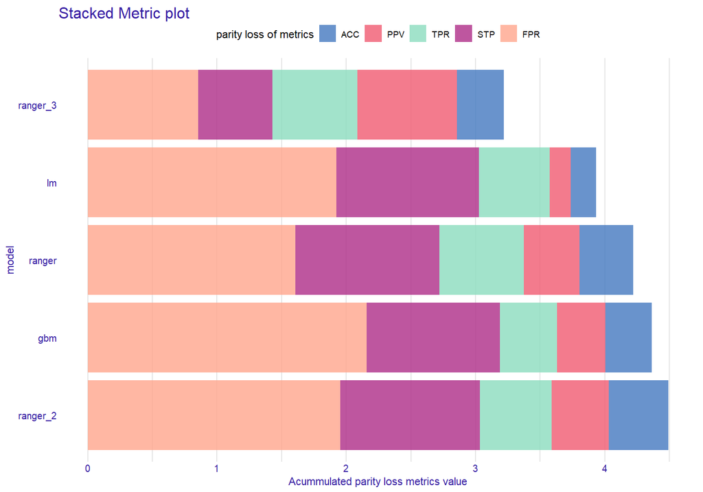

```r
sm <- stack_metrics(fobject)
plot(sm)
```

It displays accumulated (Stacked) metric scores for each model. The least metric score the better.

## 2.2 Plot metric

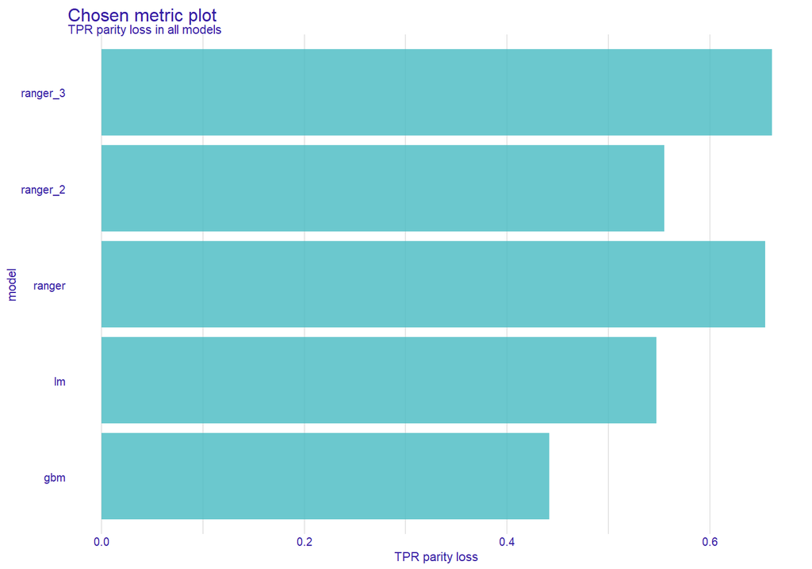

```r
cm <- choose_metric(fobject, "TPR")
plot(cm)
```

## 2.3 Plot fairness PCA

```r
fair_pca <- fairness_pca(fobject)
print(fair_pca)
```

```
#> Fairness PCA :
#>             PC1        PC2        PC3        PC4           PC5
#> [1,] -0.4376993  0.1334672  1.3835962  0.8791043  3.469447e-18
#> [2,]  3.2606330 -1.5192062  0.1942736 -0.5049678  4.829470e-15
#> [3,]  0.3199022  1.8823273  0.2012882 -0.7999178 -2.789435e-15
#> [4,] -4.2880400 -0.9163083 -0.3580275 -0.3312178  2.220446e-15
#> [5,]  1.1452042  0.4197200 -1.4211305  0.7569991 -2.713108e-15
#>
#> Created with:
#> [1] "ranger"   "lm"       "ranger_2" "ranger_3" "gbm"
#>
#> First two components explained 86 % of variance.
```

Let’s plot!

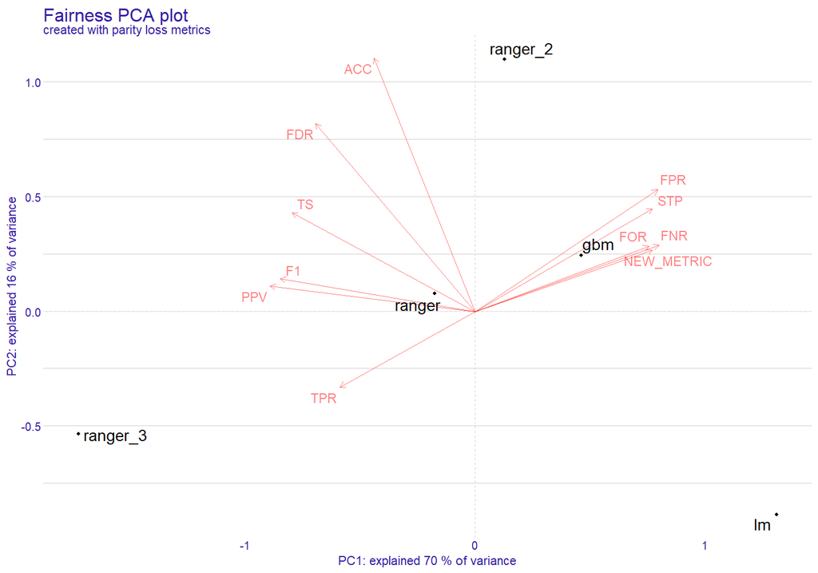

```r
plot(fair_pca)
```

## 2.4 Plot Heatmap

Another way to deal with grouped data is using heatmap.

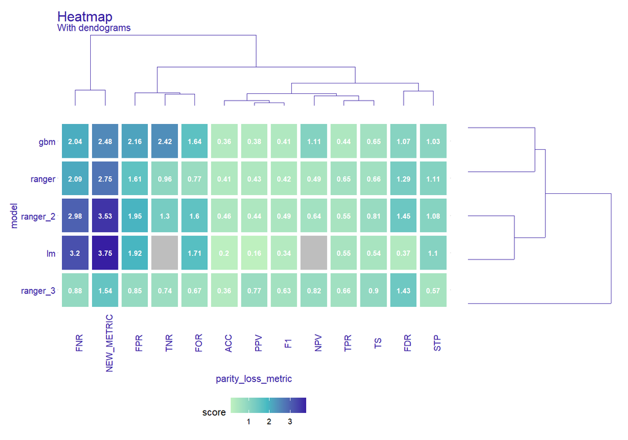

```r
fheatmap <- fairness_heatmap(fobject)
plot(fheatmap, text_size = 3)
```

For both models and metrics dendograms are created. This way through hierarchical clustering we can look on similarities between models/metrics. It should give similar but more detailed information than PCA Now we know what those scores are and how “similar” models are to each other

## 2.5 Metric and Performance Plot

Sometimes we would like to know how good are models in performance metrics and in fairness metrics at the same time, to see the tradeoff between them.

```r
fap <- performance_and_fairness(fobject, fairness_metric = "STP")
```

```
#> Performace metric is NULL, setting deafult ( accuracy )
#>
#> Creating object with:
#> Fairness metric: STP
#> Performance metric: accuracy
```

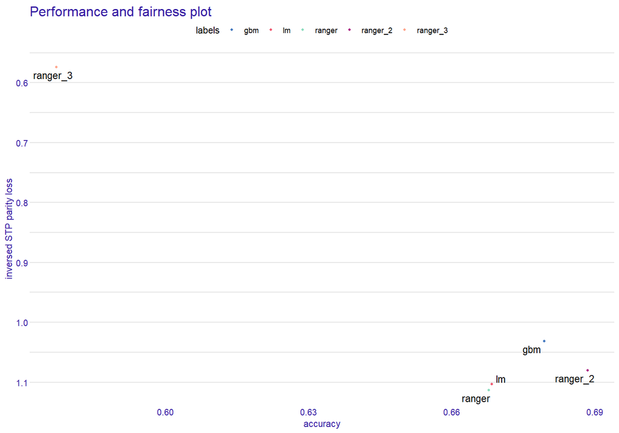

```r
plot(fap)
```

## 2.6 Group Metric

When we have narrowed down our search for the best model we can use `group_metric` to check once again metrics within groups and decide which model to use.

```r
fobject2 <- fairness_check(explainer_1,explainer_2,
                                   protected = compas$Ethnicity,
                                   privileged = "Caucasian",
                                    verbose = FALSE)


gm <- group_metric(fobject2, fairness_metric = "FPR")
```

```
#> Performace metric not given, setting deafult ( accuracy )
#>
#> Creating object with:
#> Fairness metric:  FPR
#> Performance metric:  accuracy
```

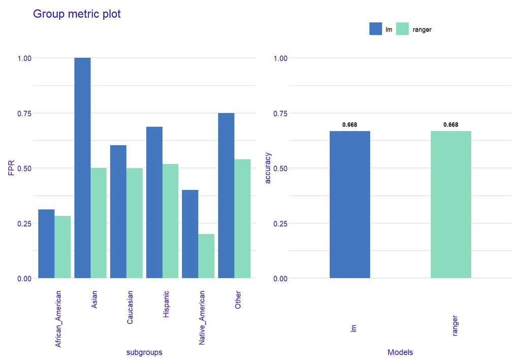

```r
plot(gm)
```

## 2.7 Radar plot

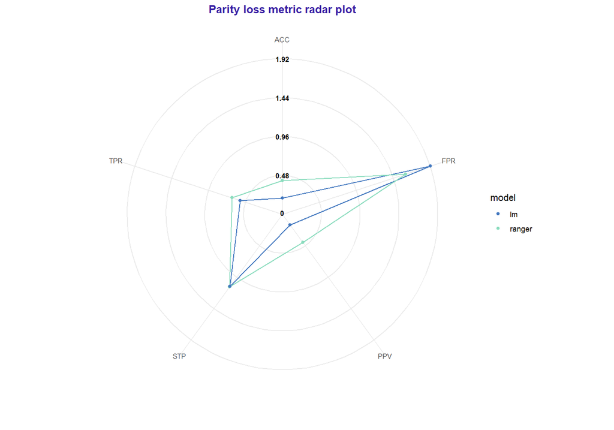

```r
fradar <- fairness_radar(fobject2)
plot(fradar)
```

## 2.8 Custom cutoff

We may see how cutoff affects parity loss of metrics

### 2.8.1 All cutoffs

All cutoffs measures where metrics exist (are not NA) and how they change if we modify cutoffs in all subgroups.

In this plot `NA` values are natural, so warnings are to be expected.

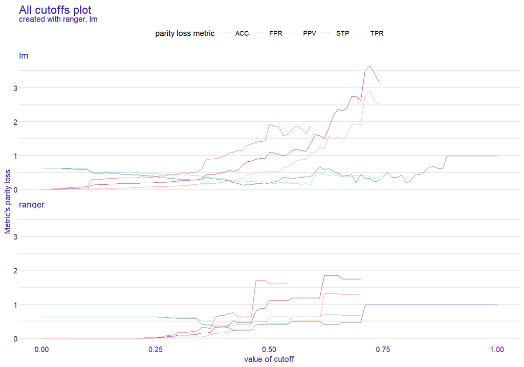

```r
ac <- all_cutoffs(fobject2)

plot(ac)
```

### 2.8.2 Ceteris paribus cutoff

This function shows how parity loss metrics would change if we modified cutoff only for one subgroup (here African American) with other cutoffs fixed.

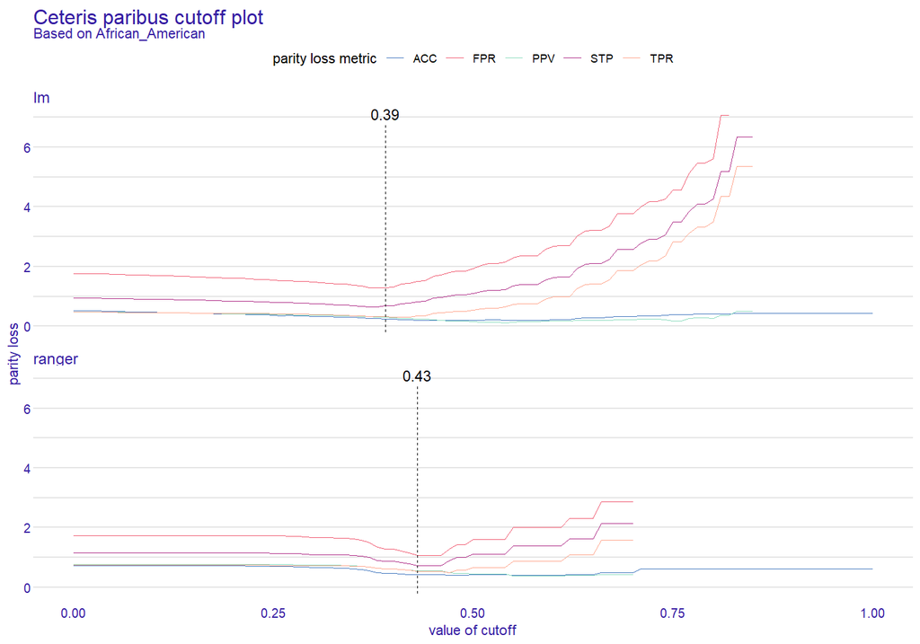

```r
cpc <- ceteris_paribus_cutoff(fobject2, subgroup = "African_American")

plot(cpc)
```

# 3 Summary

`fairmodels` is powerful and flexible tool for detecting bias and asserting fairness in models. Many metrics are available (there are tools to create own metrics based on confusion matrix). Besides bias detection `fairmodels` offers also bias mitigation. It is set of pre-processing and post-processing algorithms working either on data or on explainer which function is to lower parity loss in certain metrics. If you are interested in this and adult data case study, please check Advanced Tutorial. If you encountered a bug or you have cool idea for a new feature please write and issue [here](https://github.com/ModelOriented/fairmodels/issues).

# References

Angwin, Julia, Jeff Larson, Surya Mattu, and and Lauren Kirchner. 2016. “Machine Bias: There’s Software Used Across the Country to Predict Future Criminals. And It’s Biased Against Blacks.” *ProPublica*. https://www.propublica.org/article/machine-bias-risk-assessments-in-criminal-sentencing.

Biecek, Przemyslaw. 2018. “DALEX: Explainers for Complex Predictive Models in r.” *Journal of Machine Learning Research* 19 (84): 1–5. https://jmlr.org/papers/v19/18-416.html.

Code of Federal Regulations. 1978. “SECTION 4D, UNIFORM GUIDELINES ON EMPLOYEE SELECTION PROCEDURES (1978).” https://www.govinfo.gov/content/pkg/CFR-2014-title29-vol4/xml/CFR-2014-title29-vol4-part1607.xml.

Verma, Sahil, and Julia Rubin. 2018. “Fairness Definitions Explained.” In *Proceedings of the International Workshop on Software Fairness*, 1–7. FairWare ’18. New York, NY, USA: Association for Computing Machinery. https://doi.org/10.1145/3194770.3194776.

Wright, Marvin N., and Andreas Ziegler. 2017. “ranger: A Fast Implementation of Random Forests for High Dimensional Data in C++ and R.” *Journal of Statistical Software* 77 (1): 1–17. https://doi.org/10.18637/jss.v077.i01.